# Sparkify Small Dataset Models and Evaluation

This notebook is dedicated to the following tasks:

create a baseline model

build functions to print and graph various model evaluators

build data processing and modeling pipelines

evaluate several classifiers on train set, choose the best two

tune the best two classifiers using grid search and cross validation

plot the pr curves and the evaluation metrics of the tuned models

## Set Environment

```python
# import PySpark libraries and packages

import pyspark
from pyspark import SparkContext
from pyspark import SparkConf

from pyspark.sql import SparkSession
from pyspark.sql.window import Window as W

from pyspark.sql.types import (
    StringType,
    IntegerType,
    DateType,
    TimestampType,
    )

from pyspark.sql.functions import (
    min as Fmin, max as Fmax,
    sum as Fsum, round as Fround,

    col, lit,
    first, last,
    desc, asc,
    avg, count, countDistinct,
    when, isnull, isnan,
    from_unixtime,
    datediff,
    )

# libraries and packages for modeling

from pyspark.ml import Pipeline

from pyspark.ml.feature import (
    StringIndexer,
    OneHotEncoder,
    VectorAssembler,
    StandardScaler
)
from pyspark.ml.feature import (
    OneHotEncoder,
    OneHotEncoderModel
)

from pyspark.ml.classification import (
    LogisticRegression,
    DecisionTreeClassifier,
    RandomForestClassifier,
    GBTClassifier,
    MultilayerPerceptronClassifier,
    LinearSVC,
    NaiveBayes
)

from pyspark.ml.evaluation import BinaryClassificationEvaluator
from pyspark.ml.tuning import CrossValidator, ParamGridBuilder
```

```python
# build a Spark session using the SparkSession APIs

spark = (SparkSession
        .builder
        .appName("Sparkify")
        .getOrCreate())

spark.sparkContext.setLogLevel("ERROR")
```

```python
# import python libraries

import time
import numpy as np
import pandas as pd
import matplotlib.pyplot as plt

# import sklearn metrics related packages

from sklearn.metrics import precision_recall_curve
from sklearn.metrics import f1_score
from sklearn.metrics import auc, roc_curve, roc_auc_score
```

```python
# import library for enhanced plotting

import seaborn as sns
sns.set_style("darkgrid")
colors = sns.color_palette('PuBuGn_r')
```

## Load Train and Test Datasets

```python
def load_data(file_path):
    """
    Loads the raw dataset in Spark.

    INPUT:
            (str) - path for datafile
    OUTPUT:
            (PySpark dataframe) - dataframe of raw data

    """

    print("Loading the dataset ...")
    df = spark.read.json(file_path)
    print("Dataset is loaded...")

    return df
```

```python
def save_data(df, data_path):
    """
    Saves the PySpark dataframe to a file.

    INPUT:
            df (PySpark dataframe) - data to be saved
            data_path (str) - path for datafile
    OUTPUT:
            none

    """

    df.write.json(data_path)
```

```python
# path for the train set file
path_trainset = "data/mini_train.json"

# upload the train data
df_train = load_data(path_trainset)

# check the upload
df_train.count()
```

```
Loading the dataset ...
Dataset is loaded...
```

```
167
```

```python
# path for the test set file file
path_testset = "data/mini_test.json"

# upload the test data
df_test = load_data(path_testset)

# check the upload
df_test.count()
```

```
Loading the dataset ...
Dataset is loaded...
```

```
58
```

### Toggle the memory

```python
# add the train set to the memory
train_cached = df_train.cache()
```

```python
# add the test set to the memory
test_cached = df_test.cache()
```

## Modeling

Split the full dataset into train, test, and validation sets. Test out several of the machine learning methods you learned. Evaluate the accuracy of the various models, tuning parameters as necessary. Determine your winning model based on test accuracy and report results on the validation set. Since the churned users are a fairly small subset, I suggest using F1 score as the metric to optimize.

### Baseline Model

```python
# count the number of churn users in each set
fn_train = train_cached.where(train_cached.churn==1).count()
fn_test = test_cached.where(test_cached.churn==1).count()

# count the number of not churn users in each set
tn_train = train_cached.where(train_cached.churn==0).count()
tn_test = test_cached.where(test_cached.churn==0).count()
```

```python
# accuracy of ZeroR model on train set
accuracy_train = tn_train/(fn_train+tn_train)
print("With fp = tp = 0, fn = {} and tn = {}, the accuracy of the ZeroR model on the train set is {}%."
      .format(fn_train, tn_train, round(accuracy_train,4)*100))

# accuracy of ZeroR model on test set
accuracy_test = tn_test/(fn_test+tn_test)
print("With fp = tp = 0, fn = {} and tn = {}, the accuracy of the ZeroR model on the test set is {}%."
      .format(fn_test, tn_test, round(accuracy_test,4)*100))
```

```
With fp = tp = 0, fn = 40 and tn = 127, the accuracy of the ZeroR model on the train set is 76.05%.
With fp = tp = 0, fn = 12 and tn = 46, the accuracy of the ZeroR model on the test set is 79.31%.
```

Build a ZeroR baseline model. This is a simple model that always predicts the most numerous class. The accuracy of this model on the test set is: $${\rm accuracy\;testset} = \frac{\rm not\; churn}{\rm all\; users} = \frac{46}{58} = 0.79$$ Any classifier we build must have better accuracy on the test set than the accuracy of this dummy classifier.

### Build Models Evaluators

```python
# function to compute relevant metrics for binary classification
def conf_metrics(dataset):

    """
        Calculates the metrics associated to the confusion matrix.

        INPUT:
            dataset (pyspark.sql.DataFrame) - a dataset that contains
                                labels and predictions
        OUTPUT:
            accuracy (float) - metric
            precision (float) - metric
            recall (float) - metric
            F1 (float) - metric
    """


    # calculate the elements of the confusion matrix
    tn = dataset.where((dataset[labelCol]==0) & (dataset[predCol]==0)).count()
    tp = dataset.where((dataset[labelCol]==1) & (dataset[predCol]==1)).count()
    fn = dataset.where((dataset[labelCol]==1) & (dataset[predCol]==0)).count()
    fp = dataset.where((dataset[labelCol]==0) & (dataset[predCol]==1)).count()

    # calculate accuracy, precision, recall, and F1-score
    accuracy = (tn + tp) / (tn + tp + fn + fp)
    precision = tp / (tp + fp)
    recall = tp / (tp + fn)
    f1 =  2 * (precision*recall) / (precision + recall)

    return accuracy, precision, recall, f1
```

```python
# function to display the metrics of interest
def display_metrics(dataset, roc_cl, pr_cl):

    """
    Prints evaluation metrics for the model.

    INPUT:
         dataset (pyspark.sql.DataFrame) - a dataset that contains
                                labels and predictions

    """

    accuracy = conf_metrics(dataset)[0]
    precision = conf_metrics(dataset)[1]
    recall = conf_metrics(dataset)[2]
    f1 = conf_metrics(dataset)[3]

    print("")
    print("Confusion Matrix")
    dataset.groupBy(dataset[labelCol], dataset[predCol]).count().show()
    print("")
    print("accuracy...............%6.3f" % accuracy)
    print("precision..............%6.3f" % precision)
    print("recall.................%6.3f" % recall)
    print("F1.....................%6.3f" % f1)
    print("auc_roc................%6.3f" % roc_cl)
    print("auc_pr.................%6.3f" % pr_cl)
```

```python
# source: https://machinelearningmastery.com/roc-curves-and-precision-recall-curves-for-classification-in-python

def plot_roc_pr_curves(predictions, model_name):

    """
    Calculates ROC-AUC and PR-AUC scores and plots the ROC and PR curves.

    INPUT:
        predictions (PySpark dataframe) - contains probability predictions, label column
        model_name (str) - classifier name

    OUTPUT:
        none - two plots are displayed

    """

    # transform predictions PySpark dataframe into Pandas dataframe
    pred_pandas = predictions.select(predictions.label, predictions.probability).toPandas()

    # calculate roc_auc score
    roc_auc = roc_auc_score(pred_pandas.label, pred_pandas.probability.str[1])
    # generate a no skill prediction (majority class)
    ns_probs = [0 for _ in range(len(pred_pandas.label))]
    # calculate roc curves
    fpr, tpr, _ = roc_curve(pred_pandas.label, pred_pandas.probability.str[1])
    ns_fpr, ns_tpr, _ = roc_curve(pred_pandas.label, ns_probs)

    # calculate precision, recall for each threshold
    precision, recall, _ = precision_recall_curve(pred_pandas.label, pred_pandas.probability.str[1])
    # calculate pr auc score
    pr_auc = auc(recall, precision)


    # create figure which contains two subplots
    plt.figure(figsize=[12,6])

    plt.subplot(121)

    # plot the roc curve for the model
    plt.plot(ns_fpr, ns_tpr, linestyle='--', label='No Skill')
    plt.plot(fpr, tpr, marker='.', color='firebrick', label='ROC AUC = %.3f' % (roc_auc))

    # axis labels
    plt.xlabel('False Positive Rate')
    plt.ylabel('True Positive Rate')
    # show the legend
    plt.legend()
    # figure title
    plt.title("ROC Curve:" + model_name)

    plt.subplot(122)

    # plot the precision-recall curves

    ns_line = len(pred_pandas[pred_pandas.label==1]) / len(pred_pandas.label)
    plt.plot([0, 1], [ns_line, ns_line], linestyle='--', label='No Skill')
    plt.plot(recall, precision, marker='.', color='firebrick', label='PR AUC = %.3f' % (pr_auc))

    # axis labels
    plt.xlabel('Recall')
    plt.ylabel('Precision')
    # show the legend
    plt.legend()
    # figure title
    plt.title("Precision-Recall Curve:" + model_name)

    # show the plot
    plt.show()
```

### Build Pipelines

```python
# split the features and the label
CAT_FEATURES = ["level"]
CONT_FEATURES = ["nr_songs", "nr_likes", "nr_dislikes", "nr_friends", "nr_downgrades",
                "nr_upgrades", "nr_error", "nr_settings", "nr_ads", "nr_sessions",
                "n_acts", "acts_per_session", "songs_per_session", "ads_per_session",
                "init_days_interv", "tenure_days_interv", "active_days"]
CHURN_LABEL = "churn"

def build_full_pipeline(classifier):
    """
    Combines all the stages of the processing and modeling.
    """
    # stages in the pipeline
    stages = []

    # encode the labels
    label_indexer =  StringIndexer(inputCol=CHURN_LABEL, outputCol="label")
    stages += [label_indexer]

    # encode the binary features
    bin_assembler = VectorAssembler(inputCols=CAT_FEATURES, outputCol="bin_features")
    stages += [bin_assembler]

    # encode the continuous features
    cont_assembler = VectorAssembler(inputCols = CONT_FEATURES, outputCol="cont_features")
    stages += [cont_assembler]
    # normalize the continuous features
    cont_scaler = StandardScaler(inputCol="cont_features", outputCol="cont_scaler",
                                 withStd=True , withMean=True)
    stages += [cont_scaler]

    # pass all to the vector assembler to create a single sparse vector
    all_assembler = VectorAssembler(inputCols=["bin_features", "cont_scaler"],
                            outputCol="features")
    stages += [all_assembler]

    # add the model to the pipeline
    stages += [classifier]

    # create a pipeline
    pipeline = Pipeline(stages=stages)

    return pipeline
```

```python
# implement K-fold cross validation and grid search

def grid_search_model(pipeline, param):
    """
    Creates a cross validation object and performs grid search
    over a set of parameters.

    INPUT:
        param = grid of parameters
        pipeline = model pipeline

    OUTPUT:
        cv = cross validation object
    """
    evaluator = BinaryClassificationEvaluator()
    cv = CrossValidator(estimator=pipeline,
                    estimatorParamMaps=param,
                    evaluator=evaluator,
                    numFolds=5,
                    parallelism=2)
    return cv
```

## Evaluate PySpark Classifiers

Evaluate binary classifiers implemented in PySpark on the train set, using default parameters to select the best performing classifiers to be tuned in the next stage.

### Logistic Regression Classifier

```
Training LOGISTIC REGRESSION CLASSIFIER


Training time......... 0.050 min

Metrics on the train set

Confusion Matrix
+-----+----------+-----+
|label|prediction|count|
+-----+----------+-----+
|  1.0|       1.0|   31|
|  0.0|       1.0|    4|
|  1.0|       0.0|    9|
|  0.0|       0.0|  123|
+-----+----------+-----+


accuracy............... 0.922
precision.............. 0.886
recall................. 0.775
F1..................... 0.827
auc_roc................ 0.940
auc_pr................. 0.878
```

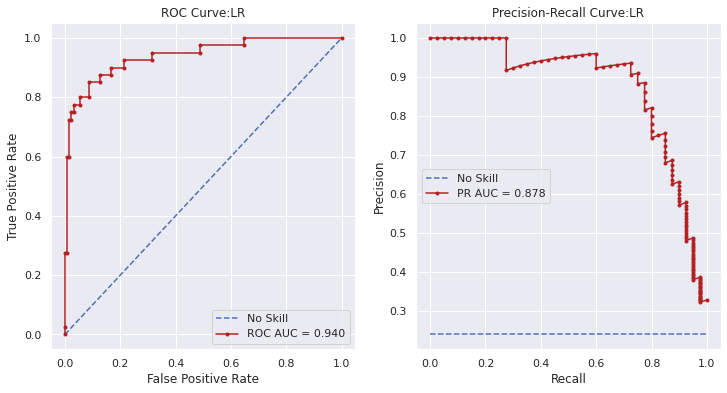

```python
print("")
print(f"Training LOGISTIC REGRESSION CLASSIFIER")
print("")

# instantiate the classifier
lr_classifier = LogisticRegression(labelCol = "label",
                                       featuresCol = "features")

# build specific pipeline
lr_pipeline = build_full_pipeline(lr_classifier)

# choose an evaluator
evaluator = BinaryClassificationEvaluator()
evaluator.setLabelCol("label")

# start timer
start_time = time.time()

# train the model
model_lr = lr_pipeline.fit(train_cached)

# stop timer
end_time = time.time()

# evaluate the trainining time in minutes
train_time = (end_time - start_time)/60

# print the training time
print("")
print("Training time.........%6.3f min" % train_time)

# create the predictions dataset
predictions_lr = model_lr.transform(train_cached)

# calculate auc metrics
roc_lr = evaluator.evaluate(predictions_lr, {evaluator.metricName: "areaUnderROC"})
pr_lr = evaluator.evaluate(predictions_lr, {evaluator.metricName: "areaUnderPR"})

# record the confusion matrix metrics
acc_lr, prec_lr, rec_lr, f1_lr = conf_metrics(predictions_lr)

# print all evaluation metrics
print("")
print("Metrics on the train set")
display_metrics(predictions_lr, roc_lr, pr_lr)
print("")

# plot the ROC and PR curves
plot_roc_pr_curves(predictions_lr, "LR")
```

### Decision Trees Classifier

```
Training DECISION TREES CLASSIFIER


Training time......... 0.009 min


Confusion Matrix
+-----+----------+-----+
|label|prediction|count|
+-----+----------+-----+
|  1.0|       1.0|   35|
|  0.0|       1.0|    1|
|  1.0|       0.0|    5|
|  0.0|       0.0|  126|
+-----+----------+-----+


accuracy............... 0.964
precision.............. 0.972
recall................. 0.875
F1..................... 0.921
auc_roc................ 0.898
auc_pr................. 0.855
```

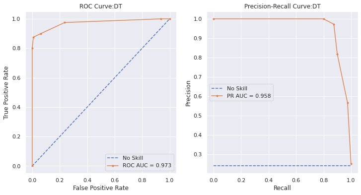

```python
print("")
print(f"Training DECISION TREES CLASSIFIER")
print("")

# build specific pipeline
dt_classifier = DecisionTreeClassifier(labelCol = "label",
                                           featuresCol = "features",
                                           seed=1234)
dt_pipeline = build_full_pipeline(dt_classifier)


# choose an evaluator
evaluator = BinaryClassificationEvaluator()
evaluator.setLabelCol("label")

# start timer
start_time = time.time()

# train the model
model_dt = dt_pipeline.fit(train_cached)

# stop timer
end_time = time.time()

# evaluate the trainining time in minutes
train_time = (end_time - start_time)/60

# print the training time
print("")
print("Training time.........%6.3f min" % train_time)

# create the predictions dataset
predictions_dt = model_dt.transform(train_cached)

# calculate auc metrics
roc_dt = evaluator.evaluate(predictions_dt, {evaluator.metricName: "areaUnderROC"})
pr_dt = evaluator.evaluate(predictions_dt, {evaluator.metricName: "areaUnderPR"})

# record the confusion matrix metrics
acc_dt, prec_dt, rec_dt, f1_dt = conf_metrics(predictions_dt)

# print all evaluation metrics
print("")
print("Metrics on the train set")
display_metrics(predictions_dt, roc_dt, pr_dt)
print("")

# plot the ROC and PR curves
plot_roc_pr_curves(predictions_dt, "DT")
```

### Random Forest Classifier

```
Training RANDOM FOREST CLASSIFIER


Training time......... 0.008 min


Confusion Matrix
+-----+----------+-----+
|label|prediction|count|
+-----+----------+-----+
|  1.0|       1.0|   36|
|  1.0|       0.0|    4|
|  0.0|       0.0|  127|
+-----+----------+-----+


accuracy............... 0.976
precision.............. 1.000
recall................. 0.900
F1..................... 0.947
auc_roc................ 0.996
auc_pr................. 0.990
```

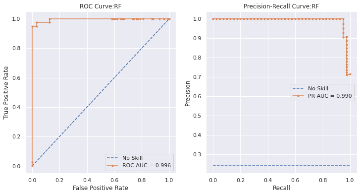

```python
print("")
print(f"Training RANDOM FOREST CLASSIFIER")
print("")

# instantiate the classifier
rf_classifier = RandomForestClassifier(labelCol = "label",
                                           featuresCol = "features",
                                           seed=1234)
# build the specific pipeline
rf_pipeline = build_full_pipeline(rf_classifier)

# choose an evaluator
evaluator = BinaryClassificationEvaluator()
evaluator.setLabelCol("label")

# start timer
start_time = time.time()

# train the model
model_rf = rf_pipeline.fit(train_cached)

# stop timer
end_time = time.time()

# evaluate the trainining time in minutes
train_time = (end_time - start_time)/60

# print the training time
print("")
print("Training time.........%6.3f min" % train_time)

# create the predictions dataset
predictions_rf = model_rf.transform(train_cached)

# calculate auc metrics
roc_rf = evaluator.evaluate(predictions_rf, {evaluator.metricName: "areaUnderROC"})
pr_rf = evaluator.evaluate(predictions_rf, {evaluator.metricName: "areaUnderPR"})

# record the confusion matrix metrics
acc_rf, prec_rf, rec_rf, f1_rf = conf_metrics(predictions_rf)

# print all evaluation metrics
print("")
print("Metrics on the train set")
display_metrics(predictions_rf, roc_rf, pr_rf)
print("")

# plot the ROC and PR curves
plot_roc_pr_curves(predictions_rf, "RF")
```

### Gradient Boosted Trees

```
Training GRADIENT BOOSTED TREES


Training time......... 0.052 min


Confusion Matrix
+-----+----------+-----+
|label|prediction|count|
+-----+----------+-----+
|  1.0|       1.0|   40|
|  0.0|       0.0|  127|
+-----+----------+-----+


accuracy............... 1.000
precision.............. 1.000
recall................. 1.000
F1..................... 1.000
auc_roc................ 1.000
auc_pr................. 1.000
```

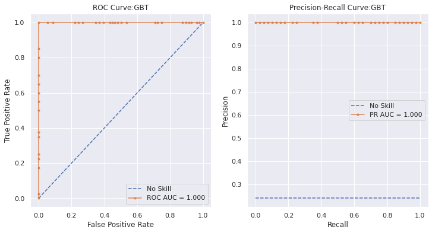

```python
print("")
print(f"Training GRADIENT BOOSTED TREES")
print("")

# instantiate the classifier
gbt_classifier = GBTClassifier(labelCol = "label",
                                featuresCol = "features",
                                seed=1234)
# build specific pipeline
gbt_pipeline = build_full_pipeline(gbt_classifier)

# choose an evaluator
evaluator = BinaryClassificationEvaluator()
evaluator.setLabelCol(labelCol)

# start timer
start_time = time.time()

# train the model
model_gbt = gbt_pipeline.fit(train_cached)

# stop timer
end_time = time.time()

# evaluate the trainining time in minutes
train_time = (end_time - start_time)/60

# print the training time
print("")
print("Training time.........%6.3f min" % train_time)

# create the predictions dataset
predictions_gbt = model_gbt.transform(train_cached)

# calculate auc metrics
roc_gbt = evaluator.evaluate(predictions_gbt, {evaluator.metricName: "areaUnderROC"})
pr_gbt = evaluator.evaluate(predictions_gbt, {evaluator.metricName: "areaUnderPR"})

# record the confusion matrix metrics
acc_gbt, prec_gbt, rec_gbt, f1_gbt = conf_metrics(predictions_gbt)

# print all evaluation metrics
print("")
print("Metrics on the train set")
display_metrics(predictions_gbt, roc_gbt, pr_gbt)
print("")

# plot the ROC and PR curves
plot_roc_pr_curves(predictions_gbt, "GBT")
```

### Multilayer Perceptron Classifier

```
Training MULTILAYER PERCEPTRON CLASSIFIER


Training time......... 0.063 min


Confusion Matrix
+-----+----------+-----+
|label|prediction|count|
+-----+----------+-----+
|  1.0|       1.0|   37|
|  0.0|       1.0|    1|
|  1.0|       0.0|    3|
|  0.0|       0.0|  126|
+-----+----------+-----+


accuracy............... 0.976
precision.............. 0.974
recall................. 0.925
F1..................... 0.949
auc_roc................ 0.987
auc_pr................. 0.960
```

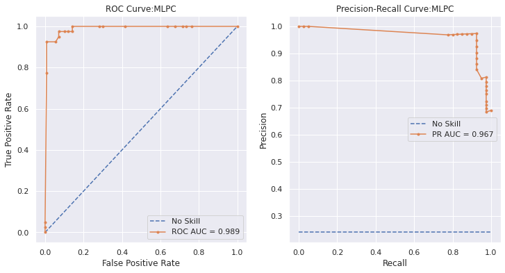

```python
print("")
print(f"Training MULTILAYER PERCEPTRON CLASSIFIER")
print("")

# specify layers: 19 (features), two intermediate (8, 4), output 2 (classes)
layers=[18, 8, 4, 2]
# create the trainer and set its parameters
mlpc_classifier = MultilayerPerceptronClassifier(labelCol = "label",
                                                featuresCol = "features",
                                                layers=layers,
                                                seed=1234)
# build specific pipeline
mlpc_pipeline = build_full_pipeline(mlpc_classifier)


# choose an evaluator
evaluator = BinaryClassificationEvaluator()
evaluator.setLabelCol("label")

# start timer
start_time = time.time()

# train the model
model_mlpc = mlpc_pipeline.fit(train_cached)

# stop timer
end_time = time.time()

# evaluate the trainining time in minutes
train_time = (end_time - start_time)/60

# print the training time
print("")
print("Training time.........%6.3f min" % train_time)

# create the predictions dataset
predictions_mlpc = model_mlpc.transform(train_cached)

# calculate auc metrics
roc_mlpc = evaluator.evaluate(predictions_mlpc, {evaluator.metricName: "areaUnderROC"})
pr_mlpc = evaluator.evaluate(predictions_mlpc, {evaluator.metricName: "areaUnderPR"})

# record the confusion matrix metrics
acc_mlpc, prec_mlpc, rec_mlpc, f1_mlpc = conf_metrics(predictions_mlpc)

# print all evaluation metrics
print("")
print("Metrics on the train set")
display_metrics(predictions_mlpc, roc_mlpc, pr_mlpc)
print("")

# plot the ROC and PR curves
plot_roc_pr_curves(predictions_mlpc, "MLPC")
```

### Linear Support Vector Machine

```python
print("")
print(f"Training LINEAR SUPPORT VECTOR MACHINE")
print("")

# instantiate the classifier
lsvc_classifier = LinearSVC(labelCol = "label",
                            featuresCol = "features")
# build specific pipeline
lsvc_pipeline = build_full_pipeline(lsvc_classifier)

# choose an evaluator
evaluator = BinaryClassificationEvaluator()
evaluator.setLabelCol("label")

# start timer
start_time = time.time()

# train the model
model_lsvc = lsvc.fit(train_cached)

# stop timer
end_time = time.time()

# evaluate the trainining time in minutes
train_time = (end_time - start_time)/60

# print the training time
print("")
print("Training time.........%6.3f min" % train_time)

# create the predictions dataset
predictions_lsvc = model_lsvc.transform(train_cached)

# calculate auc metrics
roc_lsvc = evaluator.evaluate(predictions_lsvc, {evaluator.metricName: "areaUnderROC"})
pr_lsvc = evaluator.evaluate(predictions_lsvc, {evaluator.metricName: "areaUnderPR"})

# record the confusion matrix metrics
acc_lsvc, prec_lsvc, rec_lsvc, f1_lsvc = conf_metrics(predictions_lsvc)

# print all evaluation metrics
print("")
print("Metrics on the train set")
display_metrics(predictions_lsvc, roc_lsvc, pr_lsvc)
print("")
```

```
Training LINEAR SUPPORT VECTOR MACHINE


Training time......... 0.733 min
Metrics on the train set

Confusion Matrix
+-----+----------+-----+
|label|prediction|count|
+-----+----------+-----+
|  1.0|       1.0|   30|
|  0.0|       1.0|    6|
|  1.0|       0.0|   10|
|  0.0|       0.0|  121|
+-----+----------+-----+


accuracy............... 0.904
precision.............. 0.833
recall................. 0.750
F1..................... 0.789
auc_roc................ 0.922
auc_pr................. 0.840
```

### Choose the best classifiers

```python
# create Pandas dataframe with metrics
dict_metrics = {"LinReg": [acc_lr, prec_lr, rec_lr, f1_lr, roc_lr, pr_lr],
                "DecTrees": [acc_dt, prec_dt, rec_dt, f1_dt, roc_dt, pr_dt],
                "RandForest": [acc_rf, prec_rf, rec_rf, f1_rf, roc_rf, pr_rf],
                "GradBoost": [acc_gbt, prec_gbt, rec_gbt, f1_gbt, roc_gbt, pr_gbt],
                "MultiLPerceptron": [acc_mlpc, prec_mlpc, rec_mlpc, f1_mlpc, roc_mlpc, pr_mlpc],
                "LinearSVM": [acc_lsvc, prec_lsvc, rec_lsvc, f1_lsvc, roc_lsvc, pr_lsvc],
                "list_metrics" : ["accuracy", "precision", "recall", "f1_score", "auc_roc", "auc_pr"]
               }
df_mets = pd.DataFrame.from_dict(dict_metrics).set_index("list_metrics")
df_mets.round(3)
```

[output not shown]

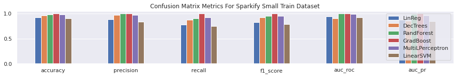

```python
# adjust figure size and font size
sns.set(rc = {"figure.figsize":(16,2)})

sns.set(font_scale=1)
ax = df_mets.plot.bar(y=["LinReg", "DecTrees", "RandForest", "GradBoost", "MultiLPerceptron", "LinearSVM"], rot=0)

# create title and labels
plt.title("Confusion Matrix Metrics For Sparkify Small Train Dataset")
ax.set_xlabel("");
ax.set_ylabel("");
```

It is clear from the table of performance metrics that Random Forest, Gradient Boosted Trees and MultiLayer Perceptron perform the best. We will use grid search with cross validation to tune Random Forest and Gradient Boosted Trees. This dataset is too small for a neural network to perform optimally, so we will skip the MultiLayer Perceptron in this case.